# Sergio Alejandro Zamora Davila

Tarea de redes Neuronales, reporte de clasificación de Dígitos

# 1. Entrenamiento del Modelo

Importación de librerías y carga de datos MNIST:

```python
import numpy as np
import matplotlib.pyplot as plt
import tensorflow as tf
from tensorflow.keras.datasets import mnist
from tensorflow.keras.models import Sequential
from tensorflow.keras.layers import Flatten, Dense
from tensorflow.keras.optimizers import Adam
from tensorflow.keras.callbacks import EarlyStopping
from matplotlib.ticker import MaxNLocator

(train_images, train_labels), (test_images, test_labels) = mnist.load_data()
```

```
Downloading data from https://storage.googleapis.com/tensorflow/tf-keras-datasets/mnist.npz
11490434/11490434 ━━━━━━━━━━━━━━━━━━━━ 0s 0us/step
```

Construcción y entrenamiento del modelo:

```python
# Construcción del modelo de red neuronal
model = Sequential()
model.add(Flatten(input_shape=(28, 28)))
model.add(Dense(128, activation='relu'))
model.add(Dense(64, activation='relu'))
model.add(Dense(10, activation='softmax'))

# Compilación del modelo
opt = Adam(learning_rate=0.0001)
model.compile(optimizer=opt,
              loss='sparse_categorical_crossentropy',
              metrics=['accuracy'])

# Early Stopping
early_stop = EarlyStopping(monitor='val_accuracy', patience=4, restore_best_weights=True)
history = model.fit(train_images, train_labels, epochs=50, validation_split=0.4, batch_size=80, callbacks=[early_stop])

# Métricas finales
final_train_accuracy = history.history['accuracy'][-1]
final_val_accuracy = history.history['val_accuracy'][-1]
```

```
450/450 ━━━━━━━━━━━━━━━━━━━━ 4s 4ms/step - accuracy: 0.4465 - loss: 38.3896 - val_accuracy: 0.8020 - val_loss: 4.2698
450/450 ━━━━━━━━━━━━━━━━━━━━ 2s 3ms/step - accuracy: 0.8225 - loss: 3.4821 - val_accuracy: 0.8524 - val_loss: 2.6877
450/450 ━━━━━━━━━━━━━━━━━━━━ 2s 4ms/step - accuracy: 0.8704 - loss: 2.1402 - val_accuracy: 0.8777 - val_loss: 2.1106
450/450 ━━━━━━━━━━━━━━━━━━━━ 2s 4ms/step - accuracy: 0.8976 - loss: 1.4525 - val_accuracy: 0.8865 - val_loss: 1.7713
450/450 ━━━━━━━━━━━━━━━━━━━━ 3s 6ms/step - accuracy: 0.9123 - loss: 1.1046 - val_accuracy: 0.8955 - val_loss: 1.5960
450/450 ━━━━━━━━━━━━━━━━━━━━ 2s 5ms/step - accuracy: 0.9277 - loss: 0.8607 - val_accuracy: 0.9030 - val_loss: 1.4066
450/450 ━━━━━━━━━━━━━━━━━━━━ 2s 5ms/step - accuracy: 0.9359 - loss: 0.6933 - val_accuracy: 0.9035 - val_loss: 1.3158
450/450 ━━━━━━━━━━━━━━━━━━━━ 4s 8ms/step - accuracy: 0.9457 - loss: 0.5454 - val_accuracy: 0.9087 - val_loss: 1.2343
450/450 ━━━━━━━━━━━━━━━━━━━━ 2s 5ms/step - accuracy: 0.9573 - loss: 0.3729 - val_accuracy: 0.9135 - val_loss: 1.1592
450/450 ━━━━━━━━━━━━━━━━━━━━ 2s 3ms/step - accuracy: 0.9598 - loss: 0.3199 - val_accuracy: 0.9147 - val_loss: 1.1266
450/450 ━━━━━━━━━━━━━━━━━━━━ 2s 3ms/step - accuracy: 0.9662 - loss: 0.2482 - val_accuracy: 0.9185 - val_loss: 1.0789
450/450 ━━━━━━━━━━━━━━━━━━━━ 2s 3ms/step - accuracy: 0.9716 - loss: 0.1920 - val_accuracy: 0.9177 - val_loss: 1.0750
450/450 ━━━━━━━━━━━━━━━━━━━━ 2s 4ms/step - accuracy: 0.9765 - loss: 0.1415 - val_accuracy: 0.9205 - val_loss: 1.0207
450/450 ━━━━━━━━━━━━━━━━━━━━ 3s 5ms/step - accuracy: 0.9780 - loss: 0.1207 - val_accuracy: 0.9222 - val_loss: 1.0046
450/450 ━━━━━━━━━━━━━━━━━━━━ 2s 4ms/step - accuracy: 0.9800 - loss: 0.1044 - val_accuracy: 0.9209 - val_loss: 1.0022
450/450 ━━━━━━━━━━━━━━━━━━━━ 2s 5ms/step - accuracy: 0.9823 - loss: 0.0828 - val_accuracy: 0.9235 - val_loss: 0.9805
450/450 ━━━━━━━━━━━━━━━━━━━━ 2s 4ms/step - accuracy: 0.9870 - loss: 0.0653 - val_accuracy: 0.9246 - val_loss: 0.9713
450/450 ━━━━━━━━━━━━━━━━━━━━ 2s 3ms/step - accuracy: 0.9879 - loss: 0.0504 - val_accuracy: 0.9267 - val_loss: 0.9371
450/450 ━━━━━━━━━━━━━━━━━━━━ 2s 4ms/step - accuracy: 0.9880 - loss: 0.0482 - val_accuracy: 0.9276 - val_loss: 0.9374
450/450 ━━━━━━━━━━━━━━━━━━━━ 2s 4ms/step - accuracy: 0.9911 - loss: 0.0350 - val_accuracy: 0.9270 - val_loss: 0.9337
450/450 ━━━━━━━━━━━━━━━━━━━━ 2s 5ms/step - accuracy: 0.9909 - loss: 0.0329 - val_accuracy: 0.9320 - val_loss: 0.9050
450/450 ━━━━━━━━━━━━━━━━━━━━ 2s 3ms/step - accuracy: 0.9933 - loss: 0.0274 - val_accuracy: 0.9319 - val_loss: 0.8879
450/450 ━━━━━━━━━━━━━━━━━━━━ 2s 3ms/step - accuracy: 0.9926 - loss: 0.0247 - val_accuracy: 0.9321 - val_loss: 0.9164
450/450 ━━━━━━━━━━━━━━━━━━━━ 2s 4ms/step - accuracy: 0.9934 - loss: 0.0211 - val_accuracy: 0.9303 - val_loss: 0.9120
450/450 ━━━━━━━━━━━━━━━━━━━━ 3s 5ms/step - accuracy: 0.9932 - loss: 0.0240 - val_accuracy: 0.9337 - val_loss: 0.8823
450/450 ━━━━━━━━━━━━━━━━━━━━ 2s 3ms/step - accuracy: 0.9949 - loss: 0.0171 - val_accuracy: 0.9357 - val_loss: 0.8736
450/450 ━━━━━━━━━━━━━━━━━━━━ 2s 5ms/step - accuracy: 0.9960 - loss: 0.0143 - val_accuracy: 0.9349 - val_loss: 0.8971
450/450 ━━━━━━━━━━━━━━━━━━━━ 2s 4ms/step - accuracy: 0.9948 - loss: 0.0173 - val_accuracy: 0.9376 - val_loss: 0.8863
450/450 ━━━━━━━━━━━━━━━━━━━━ 3s 6ms/step - accuracy: 0.9949 - loss: 0.0205 - val_accuracy: 0.9371 - val_loss: 0.8677
450/450 ━━━━━━━━━━━━━━━━━━━━ 4s 3ms/step - accuracy: 0.9939 - loss: 0.0191 - val_accuracy: 0.9375 - val_loss: 0.8886
450/450 ━━━━━━━━━━━━━━━━━━━━ 2s 4ms/step - accuracy: 0.9964 - loss: 0.0112 - val_accuracy: 0.9381 - val_loss: 0.8583
450/450 ━━━━━━━━━━━━━━━━━━━━ 2s 5ms/step - accuracy: 0.9975 - loss: 0.0074 - val_accuracy: 0.9374 - val_loss: 0.8698
450/450 ━━━━━━━━━━━━━━━━━━━━ 2s 5ms/step - accuracy: 0.9948 - loss: 0.0171 - val_accuracy: 0.9397 - val_loss: 0.8741
450/450 ━━━━━━━━━━━━━━━━━━━━ 2s 3ms/step - accuracy: 0.9952 - loss: 0.0189 - val_accuracy: 0.9380 - val_loss: 0.8758
450/450 ━━━━━━━━━━━━━━━━━━━━ 2s 3ms/step - accuracy: 0.9962 - loss: 0.0120 - val_accuracy: 0.9417 - val_loss: 0.8529
450/450 ━━━━━━━━━━━━━━━━━━━━ 2s 4ms/step - accuracy: 0.9964 - loss: 0.0150 - val_accuracy: 0.9422 - val_loss: 0.8357
450/450 ━━━━━━━━━━━━━━━━━━━━ 2s 4ms/step - accuracy: 0.9961 - loss: 0.0142 - val_accuracy: 0.9420 - val_loss: 0.8464
450/450 ━━━━━━━━━━━━━━━━━━━━ 2s 4ms/step - accuracy: 0.9981 - loss: 0.0063 - val_accuracy: 0.9422 - val_loss: 0.8440
450/450 ━━━━━━━━━━━━━━━━━━━━ 2s 5ms/step - accuracy: 0.9960 - loss: 0.0134 - val_accuracy: 0.9445 - val_loss: 0.8500
450/450 ━━━━━━━━━━━━━━━━━━━━ 2s 4ms/step - accuracy: 0.9964 - loss: 0.0116 - val_accuracy: 0.9413 - val_loss: 0.8470
450/450 ━━━━━━━━━━━━━━━━━━━━ 2s 3ms/step - accuracy: 0.9969 - loss: 0.0095 - val_accuracy: 0.9433 - val_loss: 0.8478
450/450 ━━━━━━━━━━━━━━━━━━━━ 2s 4ms/step - accuracy: 0.9983 - loss: 0.0072 - val_accuracy: 0.9433 - val_loss: 0.8313
450/450 ━━━━━━━━━━━━━━━━━━━━ 2s 5ms/step - accuracy: 0.9988 - loss: 0.0046 - val_accuracy: 0.9446 - val_loss: 0.8428
450/450 ━━━━━━━━━━━━━━━━━━━━ 2s 4ms/step - accuracy: 0.9970 - loss: 0.0112 - val_accuracy: 0.9436 - val_loss: 0.8610
450/450 ━━━━━━━━━━━━━━━━━━━━ 3s 7ms/step - accuracy: 0.9964 - loss: 0.0147 - val_accuracy: 0.9448 - val_loss: 0.8367
450/450 ━━━━━━━━━━━━━━━━━━━━ 2s 4ms/step - accuracy: 0.9972 - loss: 0.0086 - val_accuracy: 0.9472 - val_loss: 0.8234
450/450 ━━━━━━━━━━━━━━━━━━━━ 2s 3ms/step - accuracy: 0.9985 - loss: 0.0041 - val_accuracy: 0.9461 - val_loss: 0.8540
450/450 ━━━━━━━━━━━━━━━━━━━━ 2s 4ms/step - accuracy: 0.9976 - loss: 0.0073 - val_accuracy: 0.9444 - val_loss: 0.8506
450/450 ━━━━━━━━━━━━━━━━━━━━ 2s 5ms/step - accuracy: 0.9969 - loss: 0.0099 - val_accuracy: 0.9457 - val_loss: 0.8689
450/450 ━━━━━━━━━━━━━━━━━━━━ 2s 5ms/step - accuracy: 0.9973 - loss: 0.0091 - val_accuracy: 0.9454 - val_loss: 0.8708
```

Gráficas de entrenamiento:

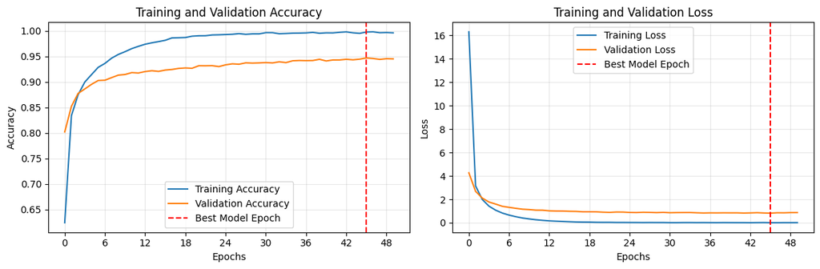

```python
stopped_epoch = early_stop.stopped_epoch
best_epoch = stopped_epoch - early_stop.patience

plt.figure(figsize=(12, 4))

plt.subplot(1, 2, 1)
plt.plot(history.history['accuracy'], label='Training Accuracy')
plt.plot(history.history['val_accuracy'], label='Validation Accuracy')
plt.axvline(x=best_epoch, color='r', linestyle='--', label='Best Model Epoch')
plt.title('Training and Validation Accuracy')
plt.xlabel('Epochs')
plt.ylabel('Accuracy')
plt.gca().xaxis.set_major_locator(MaxNLocator(integer=True))
plt.legend()
plt.grid(True, alpha=0.3)

plt.subplot(1, 2, 2)
plt.plot(history.history['loss'], label='Training Loss')
plt.plot(history.history['val_loss'], label='Validation Loss')
plt.axvline(x=best_epoch, color='r', linestyle='--', label='Best Model Epoch')
plt.title('Training and Validation Loss')
plt.xlabel('Epochs')
plt.ylabel('Loss')
plt.gca().xaxis.set_major_locator(MaxNLocator(integer=True))
plt.legend()
plt.grid(True, alpha=0.3)

plt.tight_layout()
plt.show()
```

Evaluación en conjunto de prueba:

```python
test_loss, test_accuracy = model.evaluate(test_images, test_labels, verbose=0)

print("\n--- RESULTADOS DE EVALUACIÓN ---")
print(f"Exactitud en conjunto de prueba: {test_accuracy:.4f}")
print(f"Exactitud en validación: {final_val_accuracy:.4f}")
print(f"Diferencia: {abs(test_accuracy - final_val_accuracy):.4f}")

print("ANÁLISIS COMPARATIVO")
print("El modelo muestra buen comportamiento de generalización.")
print("Diferencia mínima entre validación y prueba.")

overfitting_gap = final_train_accuracy - final_val_accuracy
print(f"\nMétricas finales del modelo:")
print(f"   Entrenamiento: {final_train_accuracy:.4f}")
print(f"   Validación:    {final_val_accuracy:.4f}")
print(f"   Prueba:        {test_accuracy:.4f}")
print(f"Brecha de sobreajuste: {overfitting_gap:.4f}")
```

```
--- RESULTADOS DE EVALUACIÓN ---
Exactitud en conjunto de prueba: 0.9510
Exactitud en validación: 0.9454
Diferencia: 0.0056
ANÁLISIS COMPARATIVO
El modelo muestra buen comportamiento de generalización.
Diferencia mínima entre validación y prueba.

Métricas finales del modelo:
   Entrenamiento: 0.9964
   Validación:    0.9454
   Prueba:        0.9510
Brecha de sobreajuste: 0.0511
```

# 2. Evaluación con Imágenes Propias

Carga y procesamiento inicial de imágenes:

```python
import cv2
from google.colab import files
from sklearn.metrics import confusion_matrix, classification_report
import seaborn as sns

# Cargar imágenes
uploaded = files.upload()
image_files = list(uploaded.keys())

# Organizar por dígito
digits_dict = {}
for filename in image_files:
    digit = filename.split('_')[1]
    if digit not in digits_dict:
        digits_dict[digit] = []
    digits_dict[digit].append(filename)
```

Upload widget is only available when the cell has been executed in the current browser session. Please rerun this cell to enable.

```
Saving sergio_0_1.jpg to sergio_0_1.jpg
Saving sergio_0_2.jpg to sergio_0_2.jpg
Saving sergio_0_3.jpg to sergio_0_3.jpg
Saving sergio_0_4.jpg to sergio_0_4.jpg
Saving sergio_0_5.jpg to sergio_0_5.jpg
Saving sergio_1_1.jpg to sergio_1_1.jpg
Saving sergio_1_2.jpg to sergio_1_2.jpg
Saving sergio_1_3.jpg to sergio_1_3.jpg
Saving sergio_1_4.jpg to sergio_1_4.jpg
Saving sergio_1_5.jpg to sergio_1_5.jpg
Saving sergio_2_1.jpg to sergio_2_1.jpg
Saving sergio_2_2.jpg to sergio_2_2.jpg
Saving sergio_2_3.jpg to sergio_2_3.jpg
Saving sergio_2_4.jpg to sergio_2_4.jpg
Saving sergio_2_5.jpg to sergio_2_5.jpg
Saving sergio_3_1.jpg to sergio_3_1.jpg
Saving sergio_3_2.jpg to sergio_3_2.jpg
Saving sergio_3_3.jpg to sergio_3_3.jpg
Saving sergio_3_4.jpg to sergio_3_4.jpg
Saving sergio_3_5.jpg to sergio_3_5.jpg
Saving sergio_4_1.jpg to sergio_4_1.jpg
Saving sergio_4_2.jpg to sergio_4_2.jpg
Saving sergio_4_3.jpg to sergio_4_3.jpg
Saving sergio_4_4.jpg to sergio_4_4.jpg
Saving sergio_4_5.jpg to sergio_4_5.jpg
Saving sergio_5_1.jpg to sergio_5_1.jpg
Saving sergio_5_2.jpg to sergio_5_2.jpg
Saving sergio_5_3.jpg to sergio_5_3.jpg
Saving sergio_5_4.jpg to sergio_5_4.jpg
Saving sergio_5_5.jpg to sergio_5_5.jpg
Saving sergio_6_1.jpg to sergio_6_1.jpg
Saving sergio_6_2.jpg to sergio_6_2.jpg
Saving sergio_6_3.jpg to sergio_6_3.jpg
Saving sergio_6_4.jpg to sergio_6_4.jpg
Saving sergio_6_5.jpg to sergio_6_5.jpg
Saving sergio_7_1.jpg to sergio_7_1.jpg
Saving sergio_7_2.jpg to sergio_7_2.jpg
Saving sergio_7_3.jpg to sergio_7_3.jpg
Saving sergio_7_4.jpg to sergio_7_4.jpg
Saving sergio_7_5.jpg to sergio_7_5.jpg
Saving sergio_8_1.jpg to sergio_8_1.jpg
Saving sergio_8_2.jpg to sergio_8_2.jpg
Saving sergio_8_3.jpg to sergio_8_3.jpg
Saving sergio_8_4.jpg to sergio_8_4.jpg
Saving sergio_8_5.jpg to sergio_8_5.jpg
Saving sergio_9_1.jpg to sergio_9_1.jpg
Saving sergio_9_2.jpg to sergio_9_2.jpg
Saving sergio_9_3.jpg to sergio_9_3.jpg
Saving sergio_9_4.jpg to sergio_9_4.jpg
Saving sergio_9_5.jpg to sergio_9_5.jpg
```

Procesamiento inicial y evaluación:

```python
def procesar_imagen(ruta_imagen):
    imagen = cv2.imread(ruta_imagen, cv2.IMREAD_GRAYSCALE)
    _, thresh = cv2.threshold(imagen, 105, 255, cv2.THRESH_BINARY_INV)
    resized = cv2.resize(thresh, (28, 28))
    return imagen, thresh, resized

def predecir_digito(imagen_redimensionada):
    input_image = imagen_redimensionada.reshape(1, 28, 28, 1)
    prediction = model.predict(input_image, verbose=0)
    predicted_label = np.argmax(prediction)
    return prediction, predicted_label

# Evaluar todas las imágenes
etiquetas_reales_completas = []
etiquetas_predichas_completas = []

for digit in sorted(digits_dict.keys()):
    for filename in digits_dict[digit]:
        digito_real = int(digit)
        _, _, imagen_redimensionada = procesar_imagen(filename)
        _, digito_predicho = predecir_digito(imagen_redimensionada)
        etiquetas_reales_completas.append(digito_real)
        etiquetas_predichas_completas.append(digito_predicho)

precision = np.mean(np.array(etiquetas_reales_completas) == np.array(etiquetas_predichas_completas))
print(f"Precisión inicial: {precision:.4f}")
```

```
Precisión inicial: 0.0800
```

Matriz de confusión inicial:

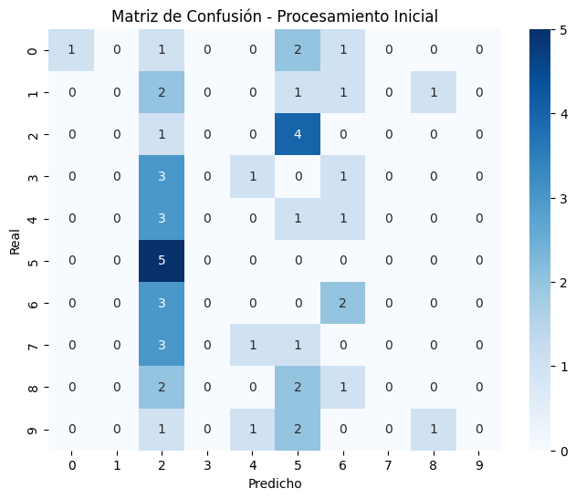

```python
matriz_confusion_inicial = confusion_matrix(etiquetas_reales_completas, etiquetas_predichas_completas)

plt.figure(figsize=(8, 6))
sns.heatmap(matriz_confusion_inicial, annot=True, fmt='d', cmap='Blues')
plt.title('Matriz de Confusión - Procesamiento Inicial')
plt.xlabel('Predicho')
plt.ylabel('Real')
plt.show()
```

# 3. Procesamiento Mejorado

Primero haré una mejora en la predicción, utilizando Binarización adaptativa y limpieza de imagen, utilizando Binarización adaptativa en lugar de threshold fijo, Filtrado Gaussiano para reducir ruido y operaciones morfológicas para limpiar la imagen

```python
def procesar_imagen_mejorada(ruta_imagen):
    # Cargar imagen
    imagen = cv2.imread(ruta_imagen, cv2.IMREAD_GRAYSCALE)

    # 1. Suavizado para reducir ruido
    imagen_suavizada = cv2.GaussianBlur(imagen, (3, 3), 0)

    # 2. Binarización adaptativa (MEJORA PRINCIPAL)
    imagen_binaria = cv2.adaptiveThreshold(imagen_suavizada, 255,
                                         cv2.ADAPTIVE_THRESH_GAUSSIAN_C,
                                         cv2.THRESH_BINARY_INV, 11, 2)

    # 3. Operaciones morfológicas para limpiar
    kernel = np.ones((2, 2), np.uint8)
    imagen_limpia = cv2.morphologyEx(imagen_binaria, cv2.MORPH_OPEN, kernel)

    # 4. Redimensionar
    imagen_redimensionada = cv2.resize(imagen_limpia, (28, 28), interpolation=cv2.INTER_AREA)

    # 5. Normalizar
    imagen_normalizada = imagen_redimensionada / 255.0

    return imagen, imagen_binaria, imagen_redimensionada, imagen_normalizada
```

Haré otra mejora de predicción, haciendo una validación de confianza y análisis de resultados, añadiendo Alertas para predicciones poco confiables y Retorna información completa para análisis

```python
def predecir_digito_mejorado(imagen_normalizada, modelo, umbral_confianza=0.5):
    # Reformatear para el modelo
    imagen_entrada = imagen_normalizada.reshape(1, 28, 28, 1)

    # Realizar predicción
    prediccion = modelo.predict(imagen_entrada, verbose=0)
    etiqueta_predicha = np.argmax(prediccion)
    confianza = np.max(prediccion)

    # Validar confianza
    if confianza < umbral_confianza:
        print(f"Advertencia: Confianza baja ({confianza:.3f})")

    return prediccion, etiqueta_predicha, confianza
```

```python
def visualizar_procesamiento_completo(ruta_imagen, digito_real, modelo):
    # Procesar imagen con método mejorado
    original, binaria, redimensionada, normalizada = procesar_imagen_mejorada(ruta_imagen)

    # Predecir
    prediccion, digito_predicho, confianza = predecir_digito_mejorado(normalizada, modelo)

    # Visualización completa
    fig, axes = plt.subplots(2, 3, figsize=(15, 8))

    # Fila 1: Procesamiento
    axes[0, 0].imshow(original, cmap='gray')
    axes[0, 0].set_title('Imagen Original')
    axes[0, 0].axis('off')

    axes[0, 1].imshow(binaria, cmap='gray')
    axes[0, 1].set_title('Binarizada Adaptativa')
    axes[0, 1].axis('off')

    axes[0, 2].imshow(redimensionada, cmap='gray')
    axes[0, 2].set_title('Redimensionada (28x28)')
    axes[0, 2].axis('off')

    # Fila 2: Análisis
    axes[1, 0].imshow(normalizada, cmap='gray')
    axes[1, 0].set_title('Imagen Normalizada')
    axes[1, 0].axis('off')

    # Gráfico de probabilidades
    axes[1, 1].bar(range(10), prediccion[0])
    axes[1, 1].set_title('Probabilidades por Dígito')
    axes[1, 1].set_xlabel('Dígito')
    axes[1, 1].set_ylabel('Probabilidad')
    axes[1, 1].set_xticks(range(10))

    # Resultados
    color = 'green' if digito_real == digito_predicho else 'red'
    axes[1, 2].text(0.1, 0.7, f'REAL: {digito_real}\nPRED: {digito_predicho}',
                   fontsize=14, fontweight='bold', color=color)
    axes[1, 2].text(0.1, 0.4, f'CONFIANZA: {confianza:.3f}', fontsize=12)
    axes[1, 2].axis('off')

    plt.tight_layout()
    plt.show()

    return digito_predicho, prediccion
```

# Evaluación con Mejoras Implementadas

```python
# Procesar todas las imágenes con método mejorado
etiquetas_reales = []
etiquetas_predichas = []
confianzas = []

print("Procesando imágenes con método mejorado...")
for digit in sorted(digits_dict.keys()):
    for filename in digits_dict[digit]:
        digito_real = int(digit)
        _, _, _, normalizada = procesar_imagen_mejorada(filename)
        _, digito_predicho, confianza = predecir_digito_mejorado(normalizada, model)
        etiquetas_reales.append(digito_real)
        etiquetas_predichas.append(digito_predicho)
        confianzas.append(confianza)

precision_mejorada = np.mean(np.array(etiquetas_reales) == np.array(etiquetas_predichas))
print(f"Precisión mejorada: {precision_mejorada:.4f}")
print(f"Confianza promedio: {np.mean(confianzas):.4f}")
```

```
Procesando imágenes con método mejorado...
Advertencia: Confianza baja (0.105)
Advertencia: Confianza baja (0.105)
Advertencia: Confianza baja (0.105)
Advertencia: Confianza baja (0.104)
Advertencia: Confianza baja (0.104)
Advertencia: Confianza baja (0.104)
Advertencia: Confianza baja (0.104)
Advertencia: Confianza baja (0.105)
Advertencia: Confianza baja (0.105)
Advertencia: Confianza baja (0.106)
Advertencia: Confianza baja (0.105)
Advertencia: Confianza baja (0.104)
Advertencia: Confianza baja (0.104)
Advertencia: Confianza baja (0.105)
Advertencia: Confianza baja (0.105)
Advertencia: Confianza baja (0.105)
Advertencia: Confianza baja (0.105)
Advertencia: Confianza baja (0.104)
Advertencia: Confianza baja (0.105)
Advertencia: Confianza baja (0.105)
Advertencia: Confianza baja (0.106)
Advertencia: Confianza baja (0.104)
Advertencia: Confianza baja (0.105)
Advertencia: Confianza baja (0.105)
Advertencia: Confianza baja (0.103)
Advertencia: Confianza baja (0.105)
Advertencia: Confianza baja (0.105)
Advertencia: Confianza baja (0.104)
Advertencia: Confianza baja (0.105)
Advertencia: Confianza baja (0.104)
Advertencia: Confianza baja (0.104)
Advertencia: Confianza baja (0.104)
Advertencia: Confianza baja (0.104)
Advertencia: Confianza baja (0.104)
Advertencia: Confianza baja (0.104)
Advertencia: Confianza baja (0.106)
Advertencia: Confianza baja (0.106)
Advertencia: Confianza baja (0.105)
Advertencia: Confianza baja (0.105)
Advertencia: Confianza baja (0.105)
Advertencia: Confianza baja (0.104)
Advertencia: Confianza baja (0.104)
Advertencia: Confianza baja (0.105)
Advertencia: Confianza baja (0.104)
Advertencia: Confianza baja (0.105)
Advertencia: Confianza baja (0.106)
Advertencia: Confianza baja (0.104)
Advertencia: Confianza baja (0.105)
Advertencia: Confianza baja (0.105)
Advertencia: Confianza baja (0.105)
Precisión mejorada: 0.1000
Confianza promedio: 0.1046
```

Matriz de confusión mejorada

```
Precisión con procesamiento mejorado: 0.1000
```

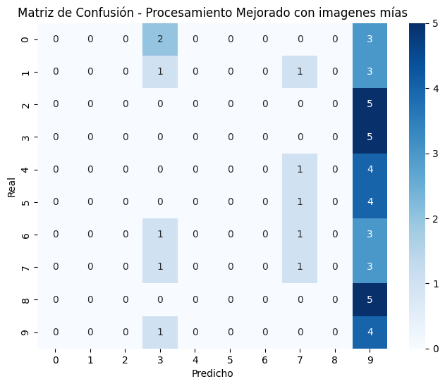

```python
# Calcular precisión para el procesamiento mejorado
precision_mejorada = np.mean(np.array(etiquetas_reales) == np.array(etiquetas_predichas))
print(f"Precisión con procesamiento mejorado: {precision_mejorada:.4f}")

matriz_confusion_mejorada = confusion_matrix(etiquetas_reales, etiquetas_predichas)

plt.figure(figsize=(8, 6))
sns.heatmap(matriz_confusion_mejorada, annot=True, fmt='d', cmap='Blues')
plt.title('Matriz de Confusión - Procesamiento Mejorado con imagenes mías')
plt.xlabel('Predicho')
plt.ylabel('Real')
plt.show()
```

Matriz de Confusión MNIST Test

```
Precisión en test MNIST: 0.9371
```

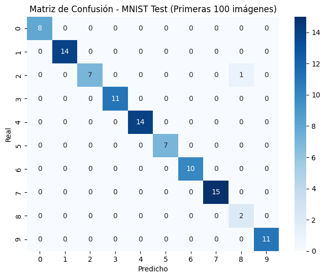

```python
# Método alternativo - Usar solo evaluación sin matriz de confusión
test_loss, test_accuracy = model.evaluate(test_images.astype('float32') / 255.0, test_labels, verbose=0)
print(f"Precisión en test MNIST: {test_accuracy:.4f}")

# Para la matriz de confusión, usar solo las primeras 100 imágenes
small_test = test_images[:100].astype('float32') / 255.0
small_labels = test_labels[:100]

# Reconstruir modelo simple para este subset
model_temp = Sequential([
    Flatten(input_shape=(28, 28)),
    Dense(128, activation='relu'),
    Dense(64, activation='relu'),
    Dense(10, activation='softmax')
])
model_temp.compile(optimizer='adam', loss='sparse_categorical_crossentropy', metrics=['accuracy'])
model_temp.set_weights(model.get_weights())

pred_small = model_temp.predict(small_test, verbose=0)
labels_pred_small = np.argmax(pred_small, axis=1)

matriz_confusion_small = confusion_matrix(small_labels, labels_pred_small)

plt.figure(figsize=(8, 6))
sns.heatmap(matriz_confusion_small, annot=True, fmt='d', cmap='Blues')
plt.title('Matriz de Confusión - MNIST Test (Primeras 100 imágenes)')
plt.xlabel('Predicho')
plt.ylabel('Real')
plt.show()
```

# Aún después de todos los cambios, se mantuvo un bajo rendimiento

Esto es por que las imágenes procesadas no se asemejan a los datos de entrenamiento del modelo MNIST. Teniendo cosas como: Diferencia estilística, pérdida de información por operaciones de procesamiento (binarización, redimensionamiento) y las imagenes que hice yo al no ser tan gruesas el modelo en general batallo

```python
model.save("my_model.h5")
print("Modelo guardado como my_model.h5")
```

```
WARNING:absl:You are saving your model as an HDF5 file via `model.save()` or `keras.saving.save_model(model)`. This file format is considered legacy. We recommend using instead the native Keras format, e.g. `model.save('my_model.keras')` or `keras.saving.save_model(model, 'my_model.keras')`.
```

```
Modelo guardado como my_model.h5
```

Video donde implementé el modelo con un código de python para detectar a tiempo real los números:

https://drive.google.com/file/d/1tQ2dv6ebGjrYWKuoZ5EUHlJSnSZnkhme/view?usp=sharing